# 2 - Sentiment analysis_SOLVED

### Most common positive and negative words

Let’s find out how much each word in the pack of novels contributes to each sentiment. This is: how many times each word appears in the novels, and which sentiment it is associated to:

```r
#create a data frame with word, sentiment and number of mentions
bing_word_counts <- tidy_austen_books %>%
  #get sentiment from bing
  inner_join(get_sentiments("bing")) %>%
  #count the number of mentions for each word
  count(word, sentiment, sort = TRUE)
bing_word_counts
```

| word | sentiment | n |
| --- | --- | --- |
| miss | negative | 1855 |
| well | positive | 1523 |
| good | positive | 1380 |
| great | positive | 981 |
| like | positive | 725 |
| better | positive | 639 |
| enough | positive | 613 |
| happy | positive | 534 |
| love | positive | 495 |
| pleasure | positive | 462 |

[output cut: 2575 more lines]

Let’s make a plot to see this in perspective.

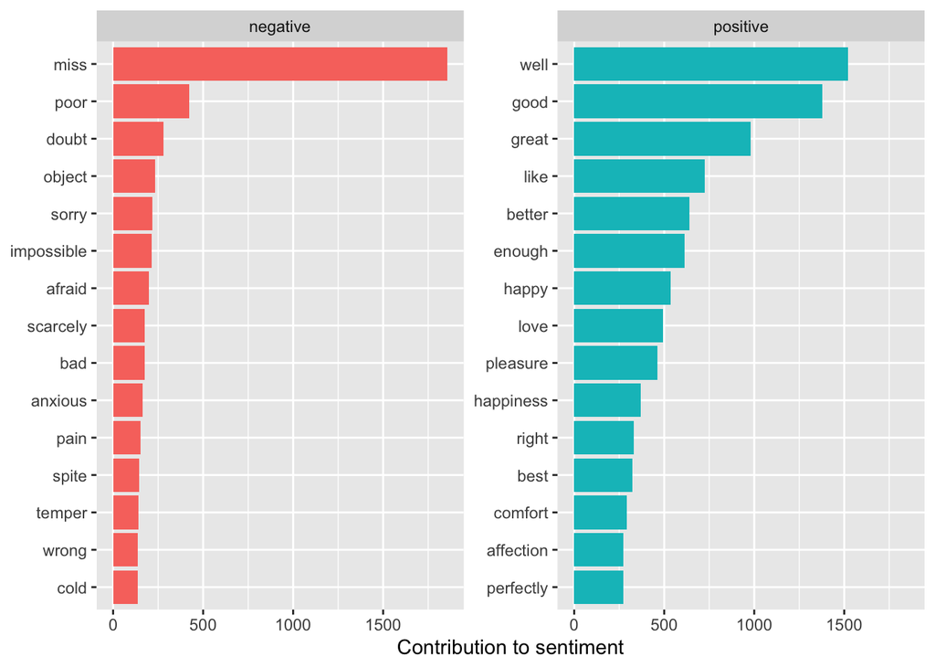

```r
bing_word_counts %>%
  group_by(sentiment) %>%
  slice_max(n, n = 15) %>%
  ungroup() %>%
  mutate(word = reorder(word, n)) %>%
  ggplot(aes(n, word, fill = sentiment)) +
  geom_col(show.legend = FALSE) +
  facet_wrap(~sentiment, scales = "free_y") +
  labs(x = "Contribution to sentiment",
       y = NULL)
```

Here’s how we discover, for example, that the word “miss” is bringing a lot of negative sentiment to the analysis. How can we fix this?

We can add “miss” to an existent stopwords list. Remember that we’ve got one in `tidytext` built upon 3 different lexicons (SMART; snowball and onix) that you can find directly in `stop_words`.

```r
stop_words
```

| word | lexicon |
| --- | --- |
| a | SMART |
| a's | SMART |
| able | SMART |
| about | SMART |
| above | SMART |
| according | SMART |
| accordingly | SMART |
| across | SMART |
| actually | SMART |
| after | SMART |

[output cut: 1139 more lines]

Now we know the aspect of the tibble, there are two columns to fill: word and lexicon it comes from. For the case of “miss”, in the lexicon column we can write just “custom”.

```r
custom_stop_words <- bind_rows(tibble(word = c("miss"),
                                      lexicon = c("custom")),
                               stop_words)

custom_stop_words
```

| word | lexicon |
| --- | --- |
| miss | custom |
| a | SMART |
| a's | SMART |
| able | SMART |
| about | SMART |
| above | SMART |
| according | SMART |
| accordingly | SMART |
| across | SMART |
| actually | SMART |

[output cut: 1140 more lines]

**Exercise:** create the same dataframe and plot, this time without “miss”. Follow these steps:

1. Filter custom stopwords
2. Create the data frame again
3. Create the plot again

```r
tidy_austen_books <- tidy_austen_books %>%
  #we use custom_stop_words instead of stop_words
  anti_join(custom_stop_words)
bing_word_counts <- tidy_austen_books %>%
  inner_join(get_sentiments("bing")) %>%
  count(word, sentiment, sort = TRUE)
bing_word_counts
```

| word | sentiment | n |
| --- | --- | --- |
| happy | positive | 534 |
| love | positive | 495 |
| pleasure | positive | 462 |
| poor | negative | 424 |
| happiness | positive | 369 |
| comfort | positive | 292 |
| doubt | negative | 281 |
| affection | positive | 272 |
| perfectly | positive | 271 |
| glad | positive | 263 |

[output cut: 2544 more lines]

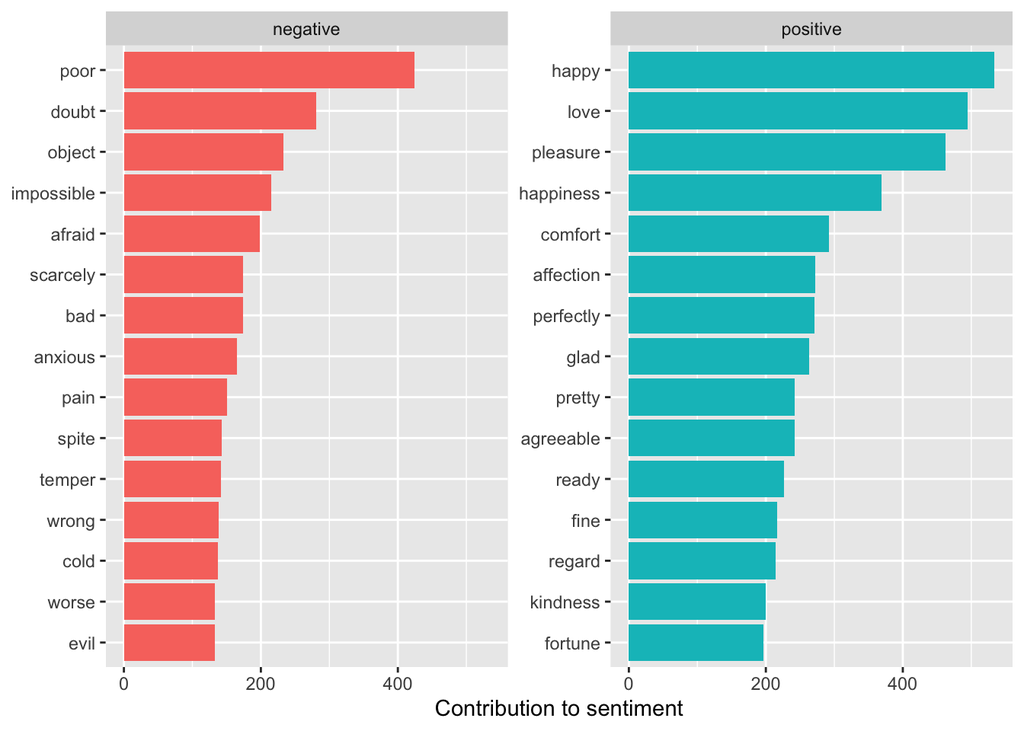

```r
bing_word_counts %>%
  group_by(sentiment) %>%
  slice_max(n, n = 15) %>%
  ungroup() %>%
  mutate(word = reorder(word, n)) %>%
  ggplot(aes(n, word, fill = sentiment)) +
  geom_col(show.legend = FALSE) +
  facet_wrap(~sentiment, scales = "free_y") +
  labs(x = "Contribution to sentiment",
       y = NULL)
```

### Most negative chapters

Next question could be: what are the most negative chapters in each of Jane Austen’s novels? To answer this question we need to extract average sentiment by chapter. The real question is: **which chapter has the highest proportion of negative words?**

We do that in a few steps:

- First, we filter negative words from Bing.
- We make a data frame with number of words per chapter.
- We find the number of negative words in each chapter and divide by the total words in chapter.

```r
#filter negative words from Bing
bingnegative <- get_sentiments("bing") %>%
  filter(sentiment == "negative")

bingnegative
```

| word | sentiment |
| --- | --- |
| 2-faces | negative |
| abnormal | negative |
| abolish | negative |
| abominable | negative |
| abominably | negative |
| abominate | negative |
| abomination | negative |
| abort | negative |
| aborted | negative |
| aborts | negative |

[output cut: 4771 more lines]

```r
# make a dataframe (wordcounts) with number of words per chapter
wordcounts <- tidy_austen_books %>%
  group_by(book, chapter) %>%
  summarize(words = n())
wordcounts
```

| book | chapter | words |
| --- | --- | --- |
| Sense & Sensibility | 0 | 5 |
| Sense & Sensibility | 1 | 533 |
| Sense & Sensibility | 2 | 497 |
| Sense & Sensibility | 3 | 504 |
| Sense & Sensibility | 4 | 591 |
| Sense & Sensibility | 5 | 339 |
| Sense & Sensibility | 6 | 426 |
| Sense & Sensibility | 7 | 455 |
| Sense & Sensibility | 8 | 377 |
| Sense & Sensibility | 9 | 617 |

[output cut: 265 more lines]

```r
#find the number of negative words by chapter and divide by the total words in chapter
tidy_austen_books %>%
  #semi_join: returns all words in books with a match in bingnegative
  semi_join(bingnegative) %>%
  #group by book and chapter to summarize how many negative words by chapter
  group_by(book, chapter) %>%
  summarize(negativewords = n()) %>%
  #left_join keeps all words in wordcounts and makes a dataframe
  left_join(wordcounts, by = c("book", "chapter")) %>%
  #create a column in the dataframe with the ratio
  mutate(ratio = negativewords/words) %>%
  #we don't want chapters 0 because they're just title and author
  filter(chapter != 0) %>%
  #we select the highest ratios
  slice_max(ratio, n = 1) %>%
  ungroup()
```

| book | chapter | negativewords | words | ratio |
| --- | --- | --- | --- | --- |
| Sense & Sensibility | 29 | 169 | 1132 | 0.1492933 |
| Pride & Prejudice | 34 | 108 | 646 | 0.1671827 |
| Mansfield Park | 45 | 127 | 879 | 0.1444824 |
| Emma | 16 | 81 | 586 | 0.1382253 |
| Northanger Abbey | 27 | 53 | 335 | 0.1582090 |
| Persuasion | 21 | 205 | 1938 | 0.1057792 |

**Exercise:** print one or two of this chapters to see with your eyes if they really are so negative.

```r
tidy_austen_books %>%
  filter(book == "Mansfield Park") %>%
  filter (chapter == 45)
```

| book | linenumber | chapter | word |
| --- | --- | --- | --- |
| Mansfield Park | 13920 | 45 | chapter |
| Mansfield Park | 13920 | 45 | xlv |
| Mansfield Park | 13922 | 45 | week's |
| Mansfield Park | 13922 | 45 | return |
| Mansfield Park | 13922 | 45 | mansfield |
| Mansfield Park | 13922 | 45 | tom's |
| Mansfield Park | 13923 | 45 | danger |
| Mansfield Park | 13923 | 45 | pronounced |
| Mansfield Park | 13923 | 45 | safe |
| Mansfield Park | 13923 | 45 | mother |

[output cut: 869 more lines]